# HDAC7_H3K9me3, exploratory H3K9me3 ChIP-seq Analysis Following HDAC7 Knockdown in Glioblastoma Stem Cells

Ola Hassan

10/5/2026

**This notebook explores the publicly available H3K9me3 ChIP-seq tracks associated with the published study, using control, HDAC7 knockdown, and input data. It focuses on genomic coverage, signal visualization, and annotation of regions selected using an exploratory 1.5-fold change threshold. The analysis complements the publication by providing a reproducible workflow for examining the deposited tracks. Results are presented descriptively, with replicate-based statistical testing outside the scope of this notebook.**

# Import the BED tables

```r
control <- read.delim(
  "data_raw/GSM8720290_gb2_sicontrol_h3k9me3.bed",
  header = FALSE,
  col.names = c("chromosome", "start", "end", "field4"),
  stringsAsFactors = FALSE
)

knockdown <- read.delim(
  "data_raw/GSM8720291_gb2_sihdac7_h3k9me3.bed",
  header = FALSE,
  col.names = c("chromosome", "start", "end", "field4"),
  stringsAsFactors = FALSE
)

head(control)
```

```
##   chromosome   start     end field4
## 1       chr1  987800  994399    253
## 2       chr1 1097400 1101999    145
## 3       chr1 1106400 1107799     50
## 4       chr1 1112800 1114799     93
## 5       chr1 1151200 1156799    228
## 6       chr1 1185200 1188799    120
```

```r
head(knockdown)
```

```
##   chromosome   start     end field4
## 1       chr1  989600  995799    203
## 2       chr1 1099800 1102399     87
## 3       chr1 1106000 1107799     58
## 4       chr1 1112600 1114399     95
## 5       chr1 1151000 1153999    163
## 6       chr1 1185000 1188799    109
```

```r
str(control)
```

```
## 'data.frame':    42090 obs. of  4 variables:
##  $ chromosome: chr  "chr1" "chr1" "chr1" "chr1" ...
##  $ start     : int  987800 1097400 1106400 1112800 1151200 1185200 1190400 1366000 1411200 1489800 ...
##  $ end       : int  994399 1101999 1107799 1114799 1156799 1188799 1196799 1367799 1412599 1493999 ...
##  $ field4    : int  253 145 50 93 228 120 290 63 53 229 ...
```

```r
str(knockdown)
```

```
## 'data.frame':    40347 obs. of  4 variables:
##  $ chromosome: chr  "chr1" "chr1" "chr1" "chr1" ...
##  $ start     : int  989600 1099800 1106000 1112600 1151000 1185000 1190400 1365800 1489600 1529400 ...
##  $ end       : int  995799 1102399 1107799 1114399 1153999 1188799 1196399 1367599 1493999 1532799 ...
##  $ field4    : int  203 87 58 95 163 109 254 67 190 170 ...
```

# Check the number of regions and coordinate validity

```r
c(
  control_regions = nrow(control),
  knockdown_regions = nrow(knockdown)
)
```

```
##   control_regions knockdown_regions
##             42090             40347
```

```r
stopifnot(
  !anyNA(control),
  !anyNA(knockdown),
  all(control$start >= 0),
  all(knockdown$start >= 0),
  all(control$end > control$start),
  all(knockdown$end > knockdown$start)
)
```

# Examine the interval lengths

```r
# Coordinate spans as stored in these files
control$coordinate_span <- control$end - control$start
knockdown$coordinate_span <- knockdown$end - knockdown$start

summary(control$coordinate_span)
```

```
##    Min. 1st Qu.  Median    Mean 3rd Qu.    Max.
##     199    2799    4199    5532    6599  322999
```

```r
summary(knockdown$coordinate_span)
```

```
##    Min. 1st Qu.  Median    Mean 3rd Qu.    Max.
##     199    2399    3599    4770    5599  210399
```

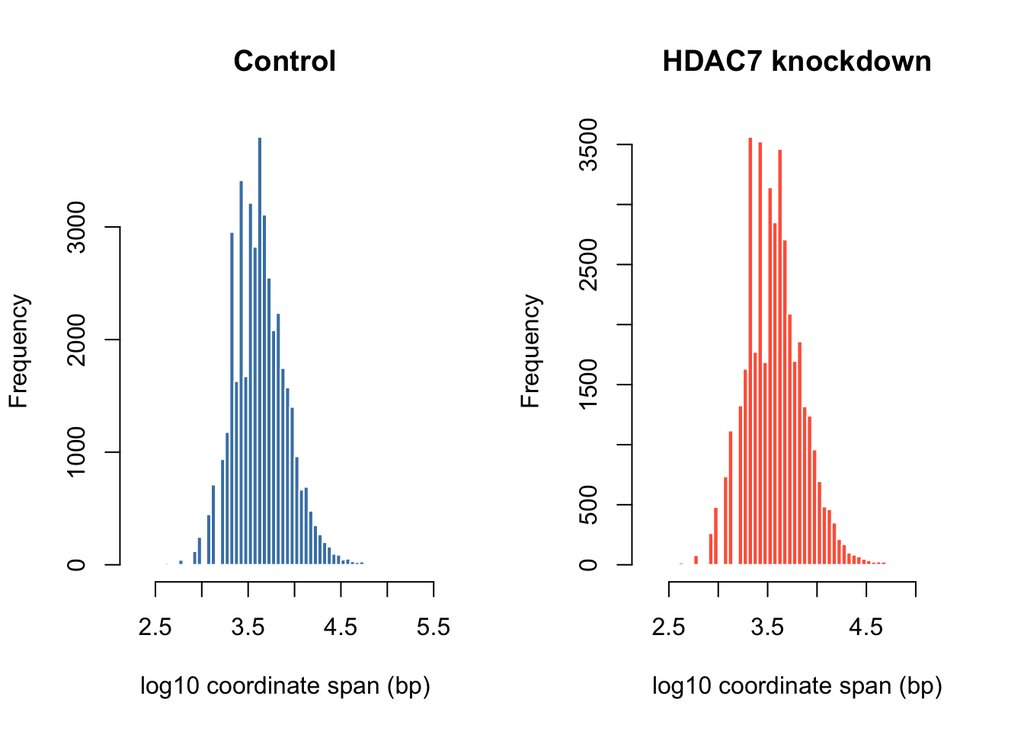

```r
par(mfrow = c(1, 2))

hist(
  log10(control$coordinate_span),
  breaks = 50,
  main = "Control",
  xlab = "log10 coordinate span (bp)",
  col = "steelblue",
  border = "white"
)

hist(
  log10(knockdown$coordinate_span),
  breaks = 50,
  main = "HDAC7 knockdown",
  xlab = "log10 coordinate span (bp)",
  col = "tomato",
  border = "white"
)
```

```r
par(mfrow = c(1, 1))

# something to get back to later that the siCT sample contains more called intervals relative to siHDAC7
```

# examine the distribution with a boxplot and check for duplicated coordinates:

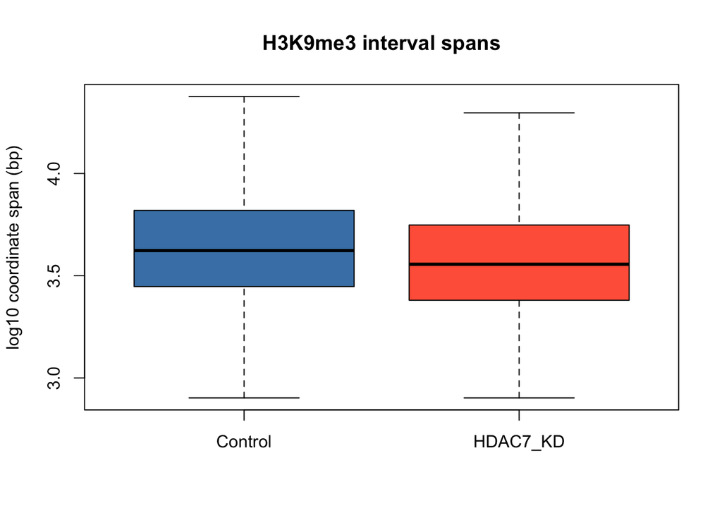

```r
# Compare the distributions on a log scale
boxplot(
  list(
    Control = log10(control$coordinate_span),
    HDAC7_KD = log10(knockdown$coordinate_span)
  ),
  ylab = "log10 coordinate span (bp)",
  main = "H3K9me3 interval spans",
  col = c("steelblue", "tomato"),
  outline = FALSE
)
```

```r
# Check for repeated genomic coordinates
c(
  control_duplicates = sum(
    duplicated(control[c("chromosome", "start", "end")])
  ),
  knockdown_duplicates = sum(
    duplicated(knockdown[c("chromosome", "start", "end")])
  )
)  # we dont have duplicates
```

```
##   control_duplicates knockdown_duplicates
##                    0                    0
```

```r
# See which chromosomes occur in each sample
table(control$chromosome)
```

```
##
##  chr1 chr10 chr11 chr12 chr13 chr14 chr15 chr16 chr17 chr18 chr19  chr2 chr20
##  3338  1433  1423  2194  1620   844   779  1087  1176  1183  1196  3733   920
## chr21 chr22  chr3  chr4  chr5  chr6  chr7  chr8  chr9  chrX  chrY
##   628   380  3438  2717  2836  3184  2522  2426  1824  1208     1
```

```r
table(knockdown$chromosome)
```

```
##
##  chr1 chr10 chr11 chr12 chr13 chr14 chr15 chr16 chr17 chr18 chr19  chr2 chr20
##  3172  1228  1344  2108  1493   766   713  1057  1127  1109  1226  3689   931
## chr21 chr22  chr3  chr4  chr5  chr6  chr7  chr8  chr9  chrX  chrY
##   632   349  3382  2503  2663  2901  2636  2371  1821  1124     2
```

```r
##Most chromosomes have fewer called intervals in knockdown, although chr7, chr19, chr20, chr21, and chrY have slightly more. Still, remember that these are peak counts only, not measurements of H3K9me3 abundance.
```

# Create genomic-range objects, how many intervals overlap between control and knockdown?

```r
library(GenomicRanges)
# Preserve the supplied coordinates for this exploratory comparison.
# Verify their convention before BED export or external annotation.
control_gr <- GRanges(
  seqnames = control$chromosome,
  ranges = IRanges(start = control$start, end = control$end)
)

knockdown_gr <- GRanges(
  seqnames = knockdown$chromosome,
  ranges = IRanges(start = knockdown$start, end = knockdown$end)
)

# TRUE if an interval overlaps at least one interval in the other sample
control_shared <- overlapsAny(control_gr, knockdown_gr)
knockdown_shared <- overlapsAny(knockdown_gr, control_gr)

overlap_summary = data.frame(
  sample = c("Control", "HDAC7 knockdown"),
  total_intervals = c(length(control_gr), length(knockdown_gr)),
  overlapping_other_sample = c(
    sum(control_shared),
    sum(knockdown_shared)
  ),
  no_overlap_other_sample = c(
    sum(!control_shared),
    sum(!knockdown_shared)
  ),
  percent_overlapping = round(
    100 * c(mean(control_shared), mean(knockdown_shared)),
    1
  )
)

overlap_summary
```

```
##            sample total_intervals overlapping_other_sample
## 1         Control           42090                    33595
## 2 HDAC7 knockdown           40347                    34792
##   no_overlap_other_sample percent_overlapping
## 1                    8495                79.8
## 2                    5555                86.2
```

```r
# Most called H3K9me3 intervals occur at shared genomic locations. However, “overlap”  here means sharing at least one base. A knockdown interval could overlap a control interval while being shorter, longer, or shifted.
# the 8,495 and 5,555 nonoverlapping intervals are sample-specific calls, rather than statistically established losses or gains yet
```

# Measure the fraction of each interval covered by the other sample’s intervals.

To avoid double-counting when multiple intervals overlap.

```r
# Combine overlapping intervals within each sample.
# min.gapwidth = 0 keeps merely adjacent intervals separate.
control_union <- reduce(control_gr, min.gapwidth = 0L)
knockdown_union <- reduce(knockdown_gr, min.gapwidth = 0L)

# Fraction of each query interval covered by the other sample
fraction_covered <- function(query, subject_union) {

  hits <- findOverlaps(query, subject_union)
  covered_bp <- numeric(length(query))

  if (length(hits) > 0L) {

    shared_pieces <- pintersect(
      query[queryHits(hits)],
      subject_union[subjectHits(hits)]
    )

    totals <- tapply(
      width(shared_pieces),
      queryHits(hits),
      sum
    )

    covered_bp[as.integer(names(totals))] <- as.numeric(totals)
  }

  covered_bp / width(query)
}

control$overlap_fraction <- fraction_covered(
  control_gr, knockdown_union
)

knockdown$overlap_fraction <- fraction_covered(
  knockdown_gr, control_union
)

summary(control$overlap_fraction)
```

```
##    Min. 1st Qu.  Median    Mean 3rd Qu.    Max.
##  0.0000  0.4167  0.7381  0.6203  0.9200  1.0000
```

```r
summary(knockdown$overlap_fraction)
```

```
##    Min. 1st Qu.  Median    Mean 3rd Qu.    Max.
##  0.0000  0.6957  0.9200  0.7640  1.0000  1.0000
```

```r
# This shows that HDAC7 Knockdown intervals are more extensively covered by control intervals than the reverse. Mean overalp is 76.4% vs 62% (Consistent with knockdown experiments)
```

# Measure total genomic coverage, counting every base only once

```r
# Genomic sequence covered by both samples
shared_union <- intersect(control_union, knockdown_union)

# Sequence covered by one sample's called regions only
control_only <- setdiff(control_union, knockdown_union)
knockdown_only <- setdiff(knockdown_union, control_union)

coverage_summary <- data.frame(
  category = c(
    "Total control coverage",
    "Total knockdown coverage",
    "Shared coverage",
    "Control-only coverage",
    "Knockdown-only coverage"
  ),
  covered_Mb = c(
    sum(as.numeric(width(control_union))),
    sum(as.numeric(width(knockdown_union))),
    sum(as.numeric(width(shared_union))),
    sum(as.numeric(width(control_only))),
    sum(as.numeric(width(knockdown_only)))
  ) / 1e6
)

coverage_summary$covered_Mb <- round(
  coverage_summary$covered_Mb, 2
)

coverage_summary
```

```
##                   category covered_Mb
## 1   Total control coverage     232.88
## 2 Total knockdown coverage     192.51
## 3          Shared coverage     156.50
## 4    Control-only coverage      76.38
## 5  Knockdown-only coverage      36.01
```

```r
# Breakingdown the coverage summary:
# Control: 156.50 + 76.38 = 232.88 Mb,  156.5/232.88 = 67.2% of control coverage overlaps knockdown


# Knockdown: 156.50 + 36.01 = 192.51 Mb,  156.50/ 192.51 = 81.3 % of knockdown coverage overlaps control

#IMP observation: Knockdown intervals are generally shorter and cover less total genomic sequence

#IMP observation: while 36.01 Mb of knockdown called regions falls outside control called regions. and 76.38 of the CTRL falls outside knockdown regions, Does this refer to gains or increased signal  at certain locations? A possibility to think about, does this mean biological contraction or redistribution of H3k9me3 bound regions
```

# check chromosome lengght acrross the three files are the same

```r
library(rtracklayer)
library(GenomicRanges)


bw_paths <- c(
  Control = "data_raw/GSM8720290_gb2_sicontrol_h3k9me3.bw",
  HDAC7_KD = "data_raw/GSM8720291_gb2_sihdac7_h3k9me3.bw",
  Input = "data_raw/GSM8720292_gb2_input_h3k9me3.bw"
)

# Confirm all three files exist
stopifnot(all(file.exists(bw_paths)))

# Create references to the files
bw_files <- lapply(bw_paths, BigWigFile)

# Examine chromosomes and chromosome lengths
seqinfo(bw_files$Control)
```

```
## Seqinfo object with 24 sequences from an unspecified genome:
##   seqnames seqlengths isCircular genome
##   chr1      248956422       <NA>   <NA>
##   chr10     133797422       <NA>   <NA>
##   chr11     135086622       <NA>   <NA>
##   chr12     133275309       <NA>   <NA>
##   chr13     114364328       <NA>   <NA>
##   ...             ...        ...    ...
##   chr7      159345973       <NA>   <NA>
##   chr8      145138636       <NA>   <NA>
##   chr9      138394717       <NA>   <NA>
##   chrX      156040895       <NA>   <NA>
##   chrY       57227415       <NA>   <NA>
```

```r
seqinfo(bw_files$HDAC7_KD)
```

```
## Seqinfo object with 24 sequences from an unspecified genome:
##   seqnames seqlengths isCircular genome
##   chr1      248956422       <NA>   <NA>
##   chr10     133797422       <NA>   <NA>
##   chr11     135086622       <NA>   <NA>
##   chr12     133275309       <NA>   <NA>
##   chr13     114364328       <NA>   <NA>
##   ...             ...        ...    ...
##   chr7      159345973       <NA>   <NA>
##   chr8      145138636       <NA>   <NA>
##   chr9      138394717       <NA>   <NA>
##   chrX      156040895       <NA>   <NA>
##   chrY       57227415       <NA>   <NA>
```

```r
seqinfo(bw_files$Input)
```

```
## Seqinfo object with 24 sequences from an unspecified genome:
##   seqnames seqlengths isCircular genome
##   chr1      248956422       <NA>   <NA>
##   chr10     133797422       <NA>   <NA>
##   chr11     135086622       <NA>   <NA>
##   chr12     133275309       <NA>   <NA>
##   chr13     114364328       <NA>   <NA>
##   ...             ...        ...    ...
##   chr7      159345973       <NA>   <NA>
##   chr8      145138636       <NA>   <NA>
##   chr9      138394717       <NA>   <NA>
##   chrX      156040895       <NA>   <NA>
##   chrY       57227415       <NA>   <NA>
```

```r
# check that the chromsomes lenghts agree across samples
```

# Reurning back to our genomic regions constructed from the bedfiles

```r
control_gr <- rtracklayer::import(
  "data_raw/GSM8720290_gb2_sicontrol_h3k9me3.bed",
  format = "BED"
)

knockdown_gr <- rtracklayer::import(
  "data_raw/GSM8720291_gb2_sihdac7_h3k9me3.bed",
  format = "BED"
)

# Retain genomic coordinates only
mcols(control_gr) <- NULL
mcols(knockdown_gr) <- NULL

# Create common regions from both samples
common_regions <- reduce(
  c(control_gr, knockdown_gr),
  min.gapwidth = 0L,
  ignore.strand = TRUE
)

length(common_regions)
```

```
## [1] 46511
```

```r
head(common_regions)
```

```
## GRanges object with 6 ranges and 0 metadata columns:
##       seqnames          ranges strand
##          <Rle>       <IRanges>  <Rle>
##   [1]     chr1   987801-995799      *
##   [2]     chr1 1097401-1102399      *
##   [3]     chr1 1106001-1107799      *
##   [4]     chr1 1112601-1114799      *
##   [5]     chr1 1151001-1156799      *
##   [6]     chr1 1185001-1188799      *
##   -------
##   seqinfo: 24 sequences from an unspecified genome; no seqlengths
```

```r
#common region are  regions formed by joining overlapping control and knockdown intervals. We will measure both samples across that same span so differences in interval boundaries do not affect the comparison area.
```

# Know lets measure peak boundries acrross all the common genomic reaions (46511)

```r
#
# Create a function to extract the mean signal
extract_region_means <- function(bw, regions, batch_size = 100L) {

  region_means <- rep(NA_real_, length(regions))

  chromosome_indices <- split(
    seq_along(regions),
    as.character(seqnames(regions))
  )

  for (chr in names(chromosome_indices)) {

    chr_idx <- chromosome_indices[[chr]]

    # Request regions in genomic order
    chr_idx <- chr_idx[
      order(start(regions[chr_idx]), end(regions[chr_idx]))
    ]

    batches <- split(
      chr_idx,
      ceiling(seq_along(chr_idx) / batch_size)
    )

    for (i in seq_along(batches)) {

      idx <- batches[[i]]

      signal <- rtracklayer::import(
        bw,
        which = regions[idx],
        as = "NumericList"
      )

      stopifnot(
        length(signal) == length(idx),
        all(
          S4Vectors::elementNROWS(signal) ==
            width(regions[idx])
        )
      )

      # Store means at their original region indices
      region_means[idx] <- vapply(
        signal, mean, numeric(1)
      )
    }

    message("Completed ", chr)
  }

  region_means
}
```

# Now Run this for both Knockdown and Ctrl

## for ctrl

```r
control_means <- extract_region_means(
  bw_files$Control,
  common_regions
)
```

```
## Completed chr1
```

```
## Completed chr10
```

```
## Completed chr11
```

```
## Completed chr12
```

```
## Completed chr13
```

```
## Completed chr14
```

```
## Completed chr15
```

```
## Completed chr16
```

```
## Completed chr17
```

```
## Completed chr18
```

```
## Completed chr19
```

```
## Completed chr2
```

```
## Completed chr20
```

```
## Completed chr21
```

```
## Completed chr22
```

```
## Completed chr3
```

```
## Completed chr4
```

```
## Completed chr5
```

```
## Completed chr6
```

```
## Completed chr7
```

```
## Completed chr8
```

```
## Completed chr9
```

```
## Completed chrX
```

```
## Completed chrY
```

## for KD

```r
knockdown_means <- extract_region_means(
  bw_files$HDAC7_KD,
  common_regions
)
```

```
## Completed chr1
```

```
## Completed chr10
```

```
## Completed chr11
```

```
## Completed chr12
```

```
## Completed chr13
```

```
## Completed chr14
```

```
## Completed chr15
```

```
## Completed chr16
```

```
## Completed chr17
```

```
## Completed chr18
```

```
## Completed chr19
```

```
## Completed chr2
```

```
## Completed chr20
```

```
## Completed chr21
```

```
## Completed chr22
```

```
## Completed chr3
```

```
## Completed chr4
```

```
## Completed chr5
```

```
## Completed chr6
```

```
## Completed chr7
```

```
## Completed chr8
```

```
## Completed chr9
```

```
## Completed chrX
```

```
## Completed chrY
```

# Now build the complete signal table

```r
region_signal <- data.frame(
  region_id = sprintf("region_%05d", seq_along(common_regions)),
  chromosome = as.character(seqnames(common_regions)),
  start = start(common_regions),
  end = end(common_regions),
  width_bp = width(common_regions),
  control_mean = control_means,
  knockdown_mean = knockdown_means
)

# Confirm the first six results match our test

nrow(region_signal)
```

```
## [1] 46511
```

```r
head(region_signal)
```

```
##      region_id chromosome   start     end width_bp control_mean knockdown_mean
## 1 region_00001       chr1  987801  995799     7999    0.2330291      0.2069009
## 2 region_00002       chr1 1097401 1102399     4999    0.2114423      0.1894379
## 3 region_00003       chr1 1106001 1107799     1799    0.2190106      0.2201223
## 4 region_00004       chr1 1112601 1114799     2199    0.3051387      0.3092315
## 5 region_00005       chr1 1151001 1156799     5799    0.2771167      0.2631488
## 6 region_00006       chr1 1185001 1188799     3799    0.2229534      0.1955778
```

# Check for missing, zero, or negative signal

```r
signal_checks <- data.frame(
  sample = c("Control", "HDAC7 knockdown"),

  nonfinite = c(
    sum(!is.finite(control_means)),
    sum(!is.finite(knockdown_means))
  ),

  zero = c(
    sum(control_means == 0, na.rm = TRUE),
    sum(knockdown_means == 0, na.rm = TRUE)
  ),

  negative = c(
    sum(control_means < 0, na.rm = TRUE),
    sum(knockdown_means < 0, na.rm = TRUE)
  )
)

signal_checks
```

```
##            sample nonfinite zero negative
## 1         Control         0    0        0
## 2 HDAC7 knockdown         0    0        0
```

```r
summary(region_signal$control_mean)
```

```
##    Min. 1st Qu.  Median    Mean 3rd Qu.    Max.
## 0.06752 0.19330 0.22647 0.23909 0.27081 5.07012
```

```r
summary(region_signal$knockdown_mean)
```

```
##    Min. 1st Qu.  Median    Mean 3rd Qu.    Max.
## 0.06106 0.16978 0.19903 0.20884 0.23613 4.74457
```

```r
#Notice, Knockdown’s overall distribution is lower than control’s
```

# 13. Now calculate the fold change within each matching region:

```r
# Require complete, positive signal before calculating ratios
stopifnot(
  nrow(region_signal) == length(common_regions),
  all(is.finite(region_signal$control_mean)),
  all(is.finite(region_signal$knockdown_mean)),
  all(region_signal$control_mean > 0),
  all(region_signal$knockdown_mean > 0)
)

region_signal$fold_change <- with(
  region_signal,
  knockdown_mean / control_mean
)

region_signal$log2FC <- log2(region_signal$fold_change)

summary(region_signal$log2FC)
```

```
##     Min.  1st Qu.   Median     Mean  3rd Qu.     Max.
## -2.14608 -0.34151 -0.20708 -0.19410 -0.06255  1.61586
```

# a 1.5-fold cutoff.

```r
# Select regions using a 1.5-fold linear change
log2_cutoff <- log2(1.5)

c(
  increased_1.5fold =
    sum(region_signal$log2FC >= log2_cutoff),

  decreased_1.5fold =
    sum(region_signal$log2FC <= -log2_cutoff),

  between_thresholds =
    sum(abs(region_signal$log2FC) < log2_cutoff)
)
```

```
##  increased_1.5fold  decreased_1.5fold between_thresholds
##                399               2484              43628
```

```r
# Store group labels for plots and downstream analysis
region_signal$selection_1.5fold <- ifelse(
  region_signal$log2FC >= log2_cutoff,
  "Higher in knockdown",
  ifelse(
    region_signal$log2FC <= -log2_cutoff,
    "Lower in knockdown",
    "Between thresholds"
  )
)

#Regions were selected using a descriptive threshold of ≥1.5-fold higher or lower normalized H3K9me3 signal in knockdown relative to control.
```

# Save the proceesed data till now

```r
dir.create("data_processed", showWarnings = FALSE)

saveRDS(
  region_signal,
  "data_processed/common_region_signal.rds"
)

write.csv(
  region_signal,
  "data_processed/common_region_signal.csv",
  row.names = FALSE
)
```

# control vs knockdown signal scatterplot visualization

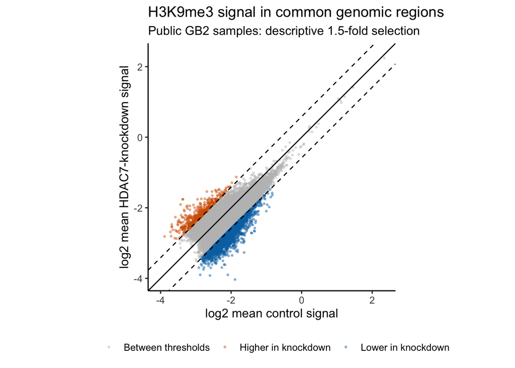

```r
library(ggplot2)
region_signal$selection_1.5fold <- factor(
  region_signal$selection_1.5fold,
  levels = c(
    "Between thresholds",
    "Higher in knockdown",
    "Lower in knockdown"
  )
)

# Draw highlighted regions after the grey background
plot_data <- region_signal[
  order(region_signal$selection_1.5fold),
]

# Use identical limits on both axes
axis_limits <- range(
  log2(c(
    region_signal$control_mean,
    region_signal$knockdown_mean
  ))
)

signal_plot <- ggplot(
  plot_data,
  aes(
    x = log2(control_mean),
    y = log2(knockdown_mean),
    color = selection_1.5fold
  )
) +
  geom_point(size = 0.6, alpha = 0.4) +

  # Equal signal
  geom_abline(
    slope = 1, intercept = 0,
    color = "black"
  ) +

  # 1.5-fold higher or lower signal
  geom_abline(
    slope = 1,
    intercept = c(log2(1.5), -log2(1.5)),
    linetype = "dashed",
    color = "black"
  ) +

  scale_color_manual(
    values = c(
      "Between thresholds" = "grey75",
      "Higher in knockdown" = "#D55E00",  #Orange ≥1.5-fold higher signal in knockdown: 399 regions
      "Lower in knockdown" = "#0072B2"    #Blue ≥1.5-fold lower signal in knockdown: 2,484 regions
    )
  ) +

  coord_fixed(
    xlim = axis_limits,
    ylim = axis_limits
  ) +

  labs(
    title = "H3K9me3 signal in common genomic regions",
    subtitle = "Public GB2 samples: descriptive 1.5-fold selection",
    x = "log2 mean control signal",
    y = "log2 mean HDAC7-knockdown signal",
    color = NULL
  ) +

  theme_classic(base_size = 12) +
  theme(legend.position = "bottom")

signal_plot
```

```r
#The plot describes differences in the tracks. It does not establish statistical significance, total cellular H3K9me3 abundance, or domain spreading.
```

# Save the figure and selected regions

```r
dir.create("figures", showWarnings = FALSE)
dir.create("data_processed", showWarnings = FALSE)

ggsave(
  "figures/H3K9me3_signal_scatter.png",
  plot = signal_plot,
  width = 8,
  height = 6,
  dpi = 300
)

higher_regions <- subset(
  region_signal,
  selection_1.5fold == "Higher in knockdown"
)

lower_regions <- subset(
  region_signal,
  selection_1.5fold == "Lower in knockdown"
)

write.csv(
  higher_regions,
  "data_processed/H3K9me3_higher_1.5fold.csv",
  row.names = FALSE
)

write.csv(
  lower_regions,
  "data_processed/H3K9me3_lower_1.5fold.csv",
  row.names = FALSE
)
```

# Let’s build center-aligned signal matrices for the two groups. We’ll use these for the profiles and heatmaps.

```r
stopifnot(
  nrow(region_signal) == length(common_regions),
  all(region_signal$start == start(common_regions)),
  all(region_signal$end == end(common_regions)),
  all(
    region_signal$chromosome ==
      as.character(seqnames(common_regions))
  )
)

higher_idx <- which(
  region_signal$selection_1.5fold == "Higher in knockdown"
)

lower_idx <- which(
  region_signal$selection_1.5fold == "Lower in knockdown"
)

c(higher = length(higher_idx), lower = length(lower_idx))
```

```
## higher  lower
##    399   2484
```

```r
#confirm that the region table and genomic ranges still match:
```

# Create the extraction function.

```r
make_center_matrix <- function(
    bw, regions, flank = 5000L, bin_size = 100L) {

  window_width <- 2L * flank
  stopifnot(window_width %% bin_size == 0L)

  centers <- start(regions) + (width(regions) - 1L) %/% 2L

  window_starts <- centers - flank
  window_ends <- centers + flank - 1L

  # Check that every complete window fits within its chromosome
  chr_lengths <- seqlengths(seqinfo(bw))[
    as.character(seqnames(regions))
  ]

  if (anyNA(chr_lengths)) {
    stop("Chromosome lengths are unavailable or names do not match.")
  }

  if (any(window_starts < 1L | window_ends > chr_lengths)) {
    stop("Some windows cross chromosome boundaries.")
  }

  windows <- GRanges(
    seqnames = seqnames(regions),
    ranges = IRanges(
      start = window_starts,
      end = window_ends
    )
  )

  result <- matrix(
    NA_real_,
    nrow = length(regions),
    ncol = window_width / bin_size
  )

  for (i in seq_along(windows)) {

    signal <- rtracklayer::import(
      bw,
      which = windows[i],
      as = "NumericList"
    )

    stopifnot(
      length(signal) == 1L,
      length(signal[[1]]) == window_width
    )

    # Each column contains 100 consecutive genomic bases
    bins <- matrix(
      as.numeric(signal[[1]]),
      nrow = bin_size
    )

    result[i, ] <- colMeans(bins)

    if (i %% 100L == 0L || i == length(windows)) {
      message("Completed ", i, " of ", length(windows), " regions")
    }
  }

  result
}
```

# create all four matrices:

```r
higher_control_matrix <- make_center_matrix(
  bw_files$Control, common_regions[higher_idx]
)
```

```
## Completed 100 of 399 regions
```

```
## Completed 200 of 399 regions
```

```
## Completed 300 of 399 regions
```

```
## Completed 399 of 399 regions
```

```r
higher_knockdown_matrix <- make_center_matrix(
  bw_files$HDAC7_KD, common_regions[higher_idx]
)
```

```
## Completed 100 of 399 regions
```

```
## Completed 200 of 399 regions
```

```
## Completed 300 of 399 regions
```

```
## Completed 399 of 399 regions
```

```r
lower_control_matrix <- make_center_matrix(
  bw_files$Control, common_regions[lower_idx]
)
```

```
## Completed 100 of 2484 regions
```

```
## Completed 200 of 2484 regions
```

```
## Completed 300 of 2484 regions
```

```
## Completed 400 of 2484 regions
```

```
## Completed 500 of 2484 regions
```

```
## Completed 600 of 2484 regions
```

```
## Completed 700 of 2484 regions
```

```
## Completed 800 of 2484 regions
```

```
## Completed 900 of 2484 regions
```

```
## Completed 1000 of 2484 regions
```

```
## Completed 1100 of 2484 regions
```

```
## Completed 1200 of 2484 regions
```

```
## Completed 1300 of 2484 regions
```

```
## Completed 1400 of 2484 regions
```

```
## Completed 1500 of 2484 regions
```

```
## Completed 1600 of 2484 regions
```

```
## Completed 1700 of 2484 regions
```

```
## Completed 1800 of 2484 regions
```

```
## Completed 1900 of 2484 regions
```

```
## Completed 2000 of 2484 regions
```

```
## Completed 2100 of 2484 regions
```

```
## Completed 2200 of 2484 regions
```

```
## Completed 2300 of 2484 regions
```

```
## Completed 2400 of 2484 regions
```

```
## Completed 2484 of 2484 regions
```

```r
lower_knockdown_matrix <- make_center_matrix(
  bw_files$HDAC7_KD, common_regions[lower_idx]
)
```

```
## Completed 100 of 2484 regions
```

```
## Completed 200 of 2484 regions
```

```
## Completed 300 of 2484 regions
```

```
## Completed 400 of 2484 regions
```

```
## Completed 500 of 2484 regions
```

```
## Completed 600 of 2484 regions
```

```
## Completed 700 of 2484 regions
```

```
## Completed 800 of 2484 regions
```

```
## Completed 900 of 2484 regions
```

```
## Completed 1000 of 2484 regions
```

```
## Completed 1100 of 2484 regions
```

```
## Completed 1200 of 2484 regions
```

```
## Completed 1300 of 2484 regions
```

```
## Completed 1400 of 2484 regions
```

```
## Completed 1500 of 2484 regions
```

```
## Completed 1600 of 2484 regions
```

```
## Completed 1700 of 2484 regions
```

```
## Completed 1800 of 2484 regions
```

```
## Completed 1900 of 2484 regions
```

```
## Completed 2000 of 2484 regions
```

```
## Completed 2100 of 2484 regions
```

```
## Completed 2200 of 2484 regions
```

```
## Completed 2300 of 2484 regions
```

```
## Completed 2400 of 2484 regions
```

```
## Completed 2484 of 2484 regions
```

# Save the matrices together with their region identifiers:

```r
saveRDS(
  list(
    higher_region_ids = region_signal$region_id[higher_idx],
    lower_region_ids = region_signal$region_id[lower_idx],
    higher_control = higher_control_matrix,
    higher_knockdown = higher_knockdown_matrix,
    lower_control = lower_control_matrix,
    lower_knockdown = lower_knockdown_matrix,
    flank_bp = 5000L,
    bin_size_bp = 100L
  ),
  "data_processed/H3K9me3_center_matrices.rds"
)
```

# Check them

```r
lapply(
  list(
    higher_control = higher_control_matrix,
    higher_knockdown = higher_knockdown_matrix,
    lower_control = lower_control_matrix,
    lower_knockdown = lower_knockdown_matrix
  ),
  dim
)
```

```
## $higher_control
## [1] 399 100
##
## $higher_knockdown
## [1] 399 100
##
## $lower_control
## [1] 2484  100
##
## $lower_knockdown
## [1] 2484  100
```

# Visulaize

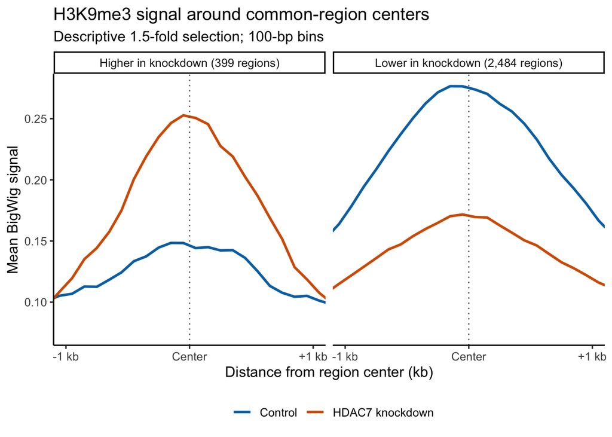

```r
library(ggplot2)

# Bin midpoints in kb, matching the extraction windows
positions_kb <- seq(
  from = -4950.5,
  by = 100,
  length.out = 100
) / 1000

profile_data <- rbind(
  data.frame(
    position_kb = positions_kb,
    signal = colMeans(higher_control_matrix),
    sample = "Control",
    group = "Higher in knockdown (399 regions)"
  ),
  data.frame(
    position_kb = positions_kb,
    signal = colMeans(higher_knockdown_matrix),
    sample = "HDAC7 knockdown",
    group = "Higher in knockdown (399 regions)"
  ),
  data.frame(
    position_kb = positions_kb,
    signal = colMeans(lower_control_matrix),
    sample = "Control",
    group = "Lower in knockdown (2,484 regions)"
  ),
  data.frame(
    position_kb = positions_kb,
    signal = colMeans(lower_knockdown_matrix),
    sample = "HDAC7 knockdown",
    group = "Lower in knockdown (2,484 regions)"
  )
)

profile_plot <- ggplot(
  profile_data,
  aes(x = position_kb, y = signal, color = sample)
) +
  geom_line(size = 1) +
  geom_vline(
    xintercept = 0,
    linetype = "dotted",
    color = "grey40"
  ) +
  facet_wrap(~ group, nrow = 1) +
  scale_color_manual(
    values = c(
      "Control" = "#0072B2",
      "HDAC7 knockdown" = "#D55E00"
    )
  ) +
  coord_cartesian(xlim = c(-1, 1)) +
  scale_x_continuous(
    breaks = c(-1, 0, 1),
    labels = c("-1 kb", "Center", "+1 kb")
  ) +
  labs(
    title = "H3K9me3 signal around common-region centers",
    subtitle = "Descriptive 1.5-fold selection; 100-bp bins",
    x = "Distance from region center (kb)",
    y = "Mean BigWig signal",
    color = NULL
  ) +
  theme_classic(base_size = 12) +
  theme(legend.position = "bottom")

print(profile_plot)
```

```r
#the main observation is a stronger signal near the center in the higher in KD (399regions). This plot supports describing higher local H3K9me3 signal at those regions. It does not, by itself, demonstrate heterochromatin spreading.


#Therfore, HDAC7 kd here shows increased mean H3K9me3 signal at 399 selected common regions and decreased signal at 2,484 selected regions. Within ±1 kb of region centers, the profiles primarily show changes in signal intensity, without clear evidence of domain broadening.
```

# save the plot

```r
dir.create("figures", showWarnings = FALSE)

ggsave(
  "figures/H3K9me3_center_profiles.png",
  plot = profile_plot,
  width = 10,
  height = 5,
  dpi = 300
)
```

# Let’s create four heatmaps, with control and knockdown side by side for each group.

```r
# Bins covering approximately ±1 kb around the center
central_bins <- 41:60

higher_order <- order(
  rowMeans(
    (higher_control_matrix[, central_bins] +
       higher_knockdown_matrix[, central_bins]) / 2
  ),
  decreasing = TRUE
)

lower_order <- order(
  rowMeans(
    (lower_control_matrix[, central_bins] +
       lower_knockdown_matrix[, central_bins]) / 2
  ),
  decreasing = TRUE
)
```

# Prepare the matrices for plotting

```r
matrix_to_table <- function(mat, row_order, group, sample) {

  mat <- mat[row_order, , drop = FALSE]

  data.frame(
    position_kb = rep(positions_kb, each = nrow(mat)),
    region_rank = rep(seq_len(nrow(mat)), times = ncol(mat)),
    signal = as.vector(mat),
    group = group,
    sample = sample
  )
}

heatmap_data <- rbind(
  matrix_to_table(
    higher_control_matrix, higher_order,
    "Higher in knockdown (399 regions)", "Control"
  ),
  matrix_to_table(
    higher_knockdown_matrix, higher_order,
    "Higher in knockdown (399 regions)", "HDAC7 knockdown"
  ),
  matrix_to_table(
    lower_control_matrix, lower_order,
    "Lower in knockdown (2,484 regions)", "Control"
  ),
  matrix_to_table(
    lower_knockdown_matrix, lower_order,
    "Lower in knockdown (2,484 regions)", "HDAC7 knockdown"
  )
)

heatmap_data$sample <- factor(
  heatmap_data$sample,
  levels = c("Control", "HDAC7 knockdown")
)

heatmap_data$group <- factor(
  heatmap_data$group,
  levels = c(
    "Higher in knockdown (399 regions)",
    "Lower in knockdown (2,484 regions)"
  )
)
```

# Draw the heatmaps

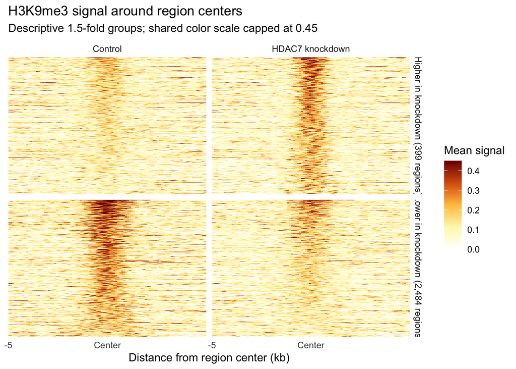

```r
color_cap <- as.numeric(
  quantile(heatmap_data$signal, 0.99)
)

heatmap_data$display_signal <- pmin(
  heatmap_data$signal,
  color_cap
)

heatmap_plot <- ggplot(
  heatmap_data,
  aes(
    x = position_kb,
    y = region_rank,
    fill = display_signal
  )
) +
  geom_raster() +
  facet_grid(group ~ sample, scales = "free_y") +
  scale_y_reverse(expand = c(0, 0)) +
  scale_x_continuous(
    breaks = c(-5, 0, 5),
    labels = c("-5", "Center", "+5"),
    expand = c(0, 0)
  ) +
  scale_fill_gradientn(
    colors = c("white", "#FFF7BC", "#FEC44F", "#D95F0E", "#7F0000"),
    limits = c(0, color_cap),
    name = "Mean signal"
  ) +
  labs(
    title = "H3K9me3 signal around region centers",
    subtitle = paste0(
      "Descriptive 1.5-fold groups; shared color scale capped at ",
      round(color_cap, 3)
    ),
    x = "Distance from region center (kb)",
    y = NULL
  ) +
  theme_minimal(base_size = 11) +
  theme(
    panel.grid = element_blank(),
    axis.text.y = element_blank(),
    axis.ticks.y = element_blank()
  )

heatmap_plot
```

# save

```r
ggsave(
  "figures/H3K9me3_center_heatmaps.png",
  plot = heatmap_plot,
  width = 10,
  height = 8,
  dpi = 300
)
```

# H3K9me3 signal profiles and Heatmaps together

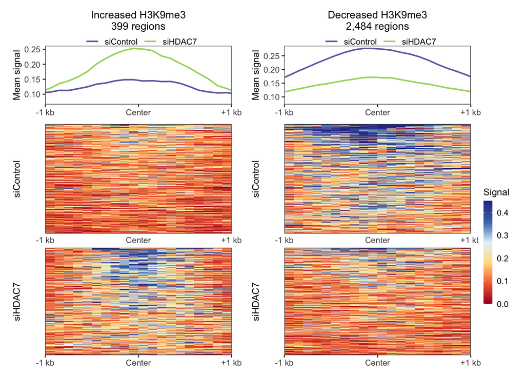

```r
library(ggplot2)
library(grid)

# Positions for the existing 100-bin matrices.
# Keep these consistent with your original extraction coordinates.
positions_kb <- seq(
  from = -4950.5,
  by = 100,
  length.out = 100
) / 1000

matrices <- list(
  higher_control_matrix,
  higher_knockdown_matrix,
  lower_control_matrix,
  lower_knockdown_matrix
)

stopifnot(
  all(vapply(matrices, ncol, integer(1)) == length(positions_kb)),
  nrow(higher_control_matrix) == nrow(higher_knockdown_matrix),
  nrow(lower_control_matrix) == nrow(lower_knockdown_matrix)
)

# Use the same row order for both conditions within each group.
# Sort by control signal near the center.
central_bins <- abs(positions_kb) <= 1

higher_order <- order(
  rowMeans(higher_control_matrix[, central_bins, drop = FALSE]),
  decreasing = TRUE
)

lower_order <- order(
  rowMeans(lower_control_matrix[, central_bins, drop = FALSE]),
  decreasing = TRUE
)

# Profile plot
make_profile <- function(control, knockdown, title) {

  dat <- rbind(
    data.frame(
      position_kb = positions_kb,
      signal = colMeans(control),
      sample = "siControl"
    ),
    data.frame(
      position_kb = positions_kb,
      signal = colMeans(knockdown),
      sample = "siHDAC7"
    )
  )

  ggplot(dat, aes(position_kb, signal, color = sample)) +
    geom_line(size = 0.7) +
    scale_color_manual(
      values = c(
        "siControl" = "#756BB1",
        "siHDAC7" = "#A6D96A"
      )
    ) +
    scale_x_continuous(
      breaks = c(-1, 0, 1),
      labels = c("-1 kb", "Center", "+1 kb"),
      expand = c(0, 0)
    ) +
    coord_cartesian(xlim = c(-1, 1)) +
    labs(
      title = title,
      x = NULL,
      y = "Mean signal",
      color = NULL
    ) +
    theme_bw(base_size = 10) +
    theme(
      panel.grid = element_blank(),
      plot.title = element_text(hjust = 0.5, size = 11),
      legend.position = "top",
      legend.text = element_text(size = 8),
      legend.key.width = unit(0.6, "cm"),
      plot.margin = margin(5, 12, 5, 5)
    )
}

# Heatmap: each row is one genomic region.
make_heatmap <- function(mat, row_order, condition,
                         show_x = FALSE, show_legend = FALSE) {

  mat <- mat[row_order, , drop = FALSE]

  dat <- data.frame(
    position_kb = rep(positions_kb, each = nrow(mat)),
    region = rep(nrow(mat):1, times = ncol(mat)),
    signal = as.vector(mat)
  )

  p <- ggplot(dat, aes(position_kb, region, fill = signal)) +
    geom_raster() +
    scale_fill_gradientn(
      colors = c(
        "#A50026",   # Low: red
        "#F46D43",
        "#FEE090",
        "#E0F3F8",
        "#4575B4",
        "#313695"    # High: blue
      ),
      limits = c(0, 0.45),
      oob = scales::squish,
      name = "Signal"
    ) +
    scale_x_continuous(
      breaks = c(-1, 0, 1),
      labels = c("-1 kb", "Center", "+1 kb"),
      expand = c(0, 0)
    ) +
    scale_y_continuous(expand = c(0, 0)) +
    coord_cartesian(xlim = c(-1, 1)) +
    labs(x = NULL, y = condition) +
    theme_bw(base_size = 10) +
    theme(
      panel.grid = element_blank(),
      axis.text.y = element_blank(),
      axis.ticks.y = element_blank(),
      axis.title.y = element_text(size = 10),
      legend.position = if (show_legend) "right" else "none",
      legend.key.height = unit(0.7, "cm"),
      plot.margin = margin(0, 12, 0, 5)
    )

  if (!show_x) {
    p <- p + theme(
      axis.text.x = element_blank(),
      axis.ticks.x = element_blank()
    )
  }

  p
}

# Create compact profile plots
profile_style <- theme(
  plot.title = element_text(size = 10, hjust = 0.5),
  axis.title.y = element_text(size = 9),
  axis.text = element_text(size = 8),
  legend.position = "top",
  legend.text = element_text(size = 8),
  legend.key.height = unit(0.3, "cm"),
  legend.key.width = unit(0.5, "cm"),
  legend.margin = margin(0, 0, 0, 0),
  legend.box.spacing = unit(0, "cm"),
  plot.margin = margin(5, 5, 5, 5)
)

p_increased <- make_profile(
  higher_control_matrix,
  higher_knockdown_matrix,
  "Increased H3K9me3\n399 regions"
) + profile_style

p_decreased <- make_profile(
  lower_control_matrix,
  lower_knockdown_matrix,
  "Decreased H3K9me3\n2,484 regions"
) + profile_style

# Compact heatmap labels
heatmap_style <- theme(
  axis.title.y = element_text(size = 9),
  axis.text.x = element_text(size = 8),
  axis.ticks.length = unit(0.08, "cm"),
  plot.margin = margin(2, 5, 2, 5)
)

h_inc_control <- make_heatmap(
  higher_control_matrix, higher_order, "siControl"
) + heatmap_style

h_inc_knockdown <- make_heatmap(
  higher_knockdown_matrix, higher_order, "siHDAC7",
  show_x = TRUE
) + heatmap_style

h_dec_control <- make_heatmap(
  lower_control_matrix, lower_order, "siControl"
) + heatmap_style

h_dec_knockdown <- make_heatmap(
  lower_knockdown_matrix, lower_order, "siHDAC7",
  show_x = TRUE
) + heatmap_style

# Extract one shared color legend
legend_source <- make_heatmap(
  lower_knockdown_matrix, lower_order, "siHDAC7",
  show_legend = TRUE
) +
  theme(
    legend.title = element_text(size = 9),
    legend.text = element_text(size = 8),
    legend.key.width = unit(0.3, "cm"),
    legend.key.height = unit(0.7, "cm")
  )

legend_gtable <- ggplotGrob(legend_source)

legend_index <- which(vapply(
  legend_gtable$grobs,
  function(g) g$name == "guide-box",
  logical(1)
))

shared_legend <- legend_gtable$grobs[[legend_index[1]]]

# Convert panels to grobs and align their plotting areas
panel_grobs <- lapply(
  list(
    p_increased, p_decreased,
    h_inc_control, h_dec_control,
    h_inc_knockdown, h_dec_knockdown
  ),
  ggplotGrob
)

common_widths <- do.call(
  unit.pmax,
  lapply(panel_grobs, function(g) g$widths)
)

panel_grobs <- lapply(panel_grobs, function(g) {
  g$widths <- common_widths
  g
})

# Draw grobs directly, with sufficient space for the profiles
draw_figure <- function() {

  grid.newpage()

  pushViewport(viewport(
    width = 0.97,
    height = 0.97,
    layout = grid.layout(
      nrow = 3,
      ncol = 4,
      heights = unit(c(0.32, 0.34, 0.34), "null"),
      widths = unit(c(1, 0.045, 1, 0.18), "null")
    )
  ))

  draw_panel <- function(grob, row, column) {
    pushViewport(viewport(
      layout.pos.row = row,
      layout.pos.col = column
    ))
    grid.draw(grob)
    popViewport()
  }

  draw_panel(panel_grobs[[1]], 1, 1)
  draw_panel(panel_grobs[[2]], 1, 3)

  draw_panel(panel_grobs[[3]], 2, 1)
  draw_panel(panel_grobs[[4]], 2, 3)

  draw_panel(panel_grobs[[5]], 3, 1)
  draw_panel(panel_grobs[[6]], 3, 3)

  draw_panel(shared_legend, 2:3, 4)

  popViewport()
}

draw_figure()
```

```r
# Visualize H3K9me3 signal around common-region centers.
# Regions are grouped using a descriptive 1.5-fold cutoff:
# 399 regions with higher signal and 2,484 with lower signal following HDAC7 knockdown.

# Each column contains average signal profiles above paired siControl and siHDAC7 heatmaps, displayed within ±1 kb.
# Regions are sorted by central siControl signal, with the same row order retained across conditions within each group.
# Heatmaps share a color scale capped at 0.45.
# These plots summarize signal intensity and variation across kd vs CT. Fold-change selection alone does not establish statistical significance, and these plots do not independently demonstrate heterochromatin spreading.
```

# Save with high reslolution

```r
# Save high-resolution PNG
png(( "figures/ H3K9me3_Signal_Profiles_and_Heatmaps.png"
  ),
  width = 8,
  height = 9,
  units = "in",
  res = 300,
  bg = "white"
)

draw_figure()
dev.off()
```

```r
# Save PDF
pdf( ("figures/ H3K9me3_Signal_Profiles_and_Heatmaps.pdf"
  ),
  width = 8,
  height = 9,
  bg = "white"
)

draw_figure()
dev.off()
```

```r
higher_input_matrix <- make_center_matrix(
  bw_files$Input,
  common_regions[higher_idx]
)
```

```
## Completed 100 of 399 regions
```

```
## Completed 200 of 399 regions
```

```
## Completed 300 of 399 regions
```

```
## Completed 399 of 399 regions
```

```r
lower_input_matrix <- make_center_matrix(
  bw_files$Input,
  common_regions[lower_idx]
)
```

```
## Completed 100 of 2484 regions
```

```
## Completed 200 of 2484 regions
```

```
## Completed 300 of 2484 regions
```

```
## Completed 400 of 2484 regions
```

```
## Completed 500 of 2484 regions
```

```
## Completed 600 of 2484 regions
```

```
## Completed 700 of 2484 regions
```

```
## Completed 800 of 2484 regions
```

```
## Completed 900 of 2484 regions
```

```
## Completed 1000 of 2484 regions
```

```
## Completed 1100 of 2484 regions
```

```
## Completed 1200 of 2484 regions
```

```
## Completed 1300 of 2484 regions
```

```
## Completed 1400 of 2484 regions
```

```
## Completed 1500 of 2484 regions
```

```
## Completed 1600 of 2484 regions
```

```
## Completed 1700 of 2484 regions
```

```
## Completed 1800 of 2484 regions
```

```
## Completed 1900 of 2484 regions
```

```
## Completed 2000 of 2484 regions
```

```
## Completed 2100 of 2484 regions
```

```
## Completed 2200 of 2484 regions
```

```
## Completed 2300 of 2484 regions
```

```
## Completed 2400 of 2484 regions
```

```
## Completed 2484 of 2484 regions
```

```r
dim(higher_input_matrix)  # Expected: 399 × 100
```

```
## [1] 399 100
```

```r
dim(lower_input_matrix)   # Expected: 2484 × 100
```

```
## [1] 2484  100
```

# H3K9me3 signal profiles for the KD vs CT vs input

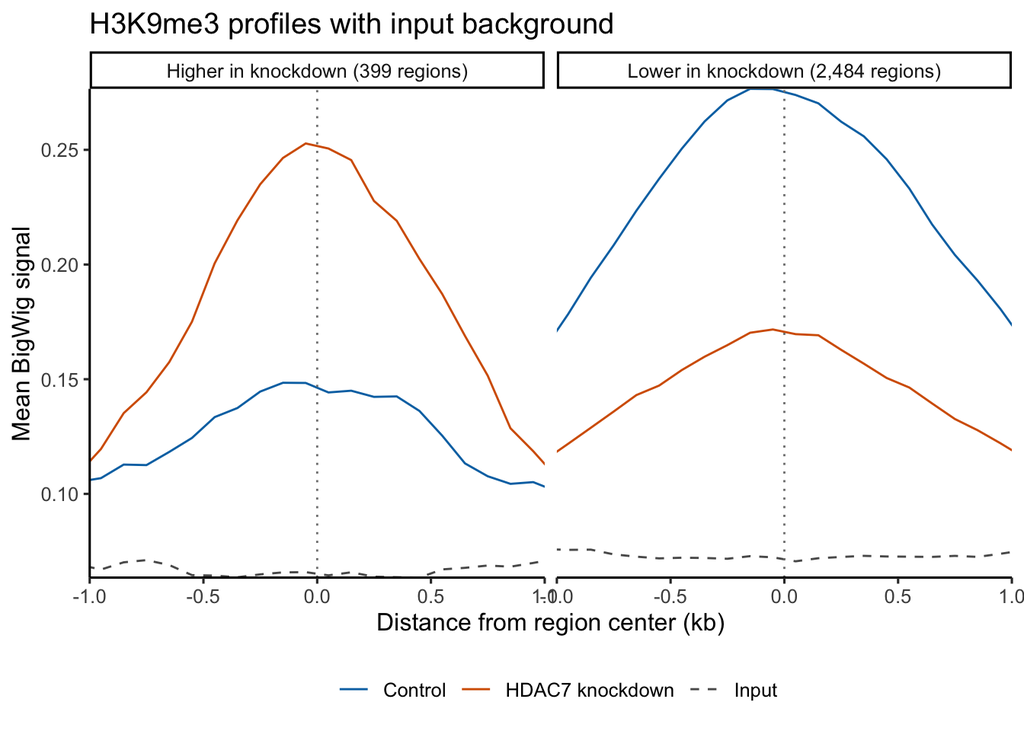

```r
profile_with_input <- rbind(
  profile_data,
  data.frame(
    position_kb = positions_kb,
    signal = colMeans(higher_input_matrix),
    sample = "Input",
    group = "Higher in knockdown (399 regions)"
  ),
  data.frame(
    position_kb = positions_kb,
    signal = colMeans(lower_input_matrix),
    sample = "Input",
    group = "Lower in knockdown (2,484 regions)"
  )
)

input_profile_plot <- ggplot(
  profile_with_input,
  aes(position_kb, signal, color = sample, linetype = sample)
) +
  geom_line(linewidth = 0.9) +
  geom_vline(
    xintercept = 0,
    linetype = "dotted",
    color = "grey50"
  ) +
  facet_wrap(~ group, nrow = 1) +
  scale_x_continuous(
    breaks = c(-1, -0.5, 0, 0.5, 1)
  ) +
  coord_cartesian(
    xlim = c(-1, 1),
    expand = FALSE
  )+
  scale_color_manual(
    values = c(
      "Control" = "#0072B2",
      "HDAC7 knockdown" = "#D55E00",
      "Input" = "grey35"
    )
  ) +
  scale_linetype_manual(
    values = c(
      "Control" = "solid",
      "HDAC7 knockdown" = "solid",
      "Input" = "dashed"
    )
  ) +
  labs(
    title = "H3K9me3 profiles with input background",
    x = "Distance from region center (kb)",
    y = "Mean BigWig signal",
    color = NULL,
    linetype = NULL
  ) +
  theme_classic(base_size = 12) +
  theme(legend.position = "bottom")
input_profile_plot
```

```r
#the input has no central peak in either group (the dashed grey curve remains relatively flat,)
```

# Gene anotation

### We’ll annotate all 46,511 common regions first,

### We’ll use ChIPseeker with hg38, we’ll define a promoter as −3 kb to +1 kb around the transcription start site (TSS).

```r
library(ChIPseeker)
library(TxDb.Hsapiens.UCSC.hg38.knownGene)
library(org.Hs.eg.db)
#Check that the regions match your signal table to prevent assigning a gene to the wrong signal row.

stopifnot(
  length(common_regions) == nrow(region_signal),
  !anyDuplicated(region_signal$region_id),
  all(as.character(seqnames(common_regions)) ==
        as.character(region_signal$chromosome)),
  all(start(common_regions) == region_signal$start),
  all(end(common_regions) == region_signal$end)
)

# Work on a copy and attach the existing region identifiers
regions_to_annotate <- common_regions

mcols(regions_to_annotate)$region_id <-
  as.character(region_signal$region_id)
```

### Annotate common regions

```r
txdb <- TxDb.Hsapiens.UCSC.hg38.knownGene

common_annotation <- annotatePeak(
  regions_to_annotate,
  TxDb = txdb,
  annoDb = "org.Hs.eg.db",
  tssRegion = c(-3000, 1000),
  level = "transcript",
  verbose = TRUE
)
```

```
## >> preparing features information...      2026-10-07 19:55:53
## >> identifying nearest features...        2026-10-07 19:55:53
## >> calculating distance from peak to TSS...   2026-10-07 19:55:54
## >> assigning genomic annotation...        2026-10-07 19:55:54
## >> adding gene annotation...          2026-10-07 19:56:11
```

```
## >> assigning chromosome lengths           2026-10-07 19:56:11
## >> done...                    2026-10-07 19:56:11
```

```r
annotation_table <- as.data.frame(common_annotation)

head(
  annotation_table[
    ,
    c(
      "region_id",
      "seqnames",
      "start",
      "end",
      "annotation",
      "geneId",
      "SYMBOL",
      "distanceToTSS"
    )
  ]
)
```

```
##      region_id seqnames   start     end
## 1 region_00001     chr1  987801  995799
## 2 region_00002     chr1 1097401 1102399
## 3 region_00003     chr1 1106001 1107799
## 4 region_00004     chr1 1112601 1114799
## 5 region_00005     chr1 1151001 1156799
## 6 region_00006     chr1 1185001 1188799
##                                                annotation geneId   SYMBOL
## 1                                       Distal Intergenic  57801     HES4
## 2 Exon (ENST00000648183.1/ENST00000648183.1, exon 1 of 2)  54991 C1orf159
## 3                                        Promoter (<=1kb)  54991 C1orf159
## 4        Intron (ENST00000379339.5/54991, intron 2 of 11)  54991 C1orf159
## 5                                       Distal Intergenic 406984  MIR200B
## 6                                        Promoter (<=1kb) 254173   TTLL10
##   distanceToTSS
## 1          4182
## 2          3728
## 3             0
## 4          1282
## 5        -10305
## 6             0
```

### Match by region identifier rather than assuming annotation preserves row order.

```r
signal_row <- match(
  annotation_table$region_id,
  region_signal$region_id
)

stopifnot(
  nrow(annotation_table) == nrow(region_signal),
  !anyDuplicated(annotation_table$region_id),
  !anyNA(signal_row)
)

annotated_regions <- annotation_table

signal_columns <- c(
  "control_mean",
  "knockdown_mean",
  "fold_change",
  "log2FC",
  "selection_1.5fold"
)

annotated_regions[signal_columns] <-
  region_signal[signal_row, signal_columns, drop = FALSE]
```

```r
annotated_regions$feature <- sub(
  "\\s*\\(.*$",
  "",
  annotated_regions$annotation
)

feature_counts <- with(
  annotated_regions,
  table(
    group = selection_1.5fold,
    feature = feature
  )
)

feature_percentages <- round(
  100 * prop.table(feature_counts, margin = 1),
  1
)

feature_counts
```

```
##                      feature
## group                 3' UTR 5' UTR Distal Intergenic Downstream  Exon Intron
##   Between thresholds    1226    410             15602        303  4974  16258
##   Higher in knockdown      2      3               178          3    24    165
##   Lower in knockdown      38      9              1013         18   201   1024
##                      feature
## group                 Promoter
##   Between thresholds      4855
##   Higher in knockdown       24
##   Lower in knockdown       181
```

```r
feature_percentages
```

```
##                      feature
## group                 3' UTR 5' UTR Distal Intergenic Downstream Exon Intron
##   Between thresholds     2.8    0.9              35.8        0.7 11.4   37.3
##   Higher in knockdown    0.5    0.8              44.6        0.8  6.0   41.4
##   Lower in knockdown     1.5    0.4              40.8        0.7  8.1   41.2
##                      feature
## group                 Promoter
##   Between thresholds      11.1
##   Higher in knockdown      6.0
##   Lower in knockdown       7.3
```

```r
#difference were predominantly assigned to intronic and distal intergenic locations.
```

# Genome browser tracks for the three regions with the largest increases in H3K9me3 signal.

```r
higher_regions <- subset(
  annotated_regions,
  selection_1.5fold == "Higher in knockdown"
)

higher_regions <- higher_regions[
  order(
    -higher_regions$fold_change,
    as.character(higher_regions$seqnames),
    higher_regions$start
  ),
]

top_loci <- head(higher_regions, 3)

top_loci[
  ,
  c(
    "region_id",
    "seqnames",
    "start",
    "end",
    "SYMBOL",
    "annotation",
    "fold_change"
  )
]
```

```
##          region_id seqnames    start      end    SYMBOL
## 18665 region_18665     chr6 34253001 34253799    SMIM29
## 44154 region_44154    chr21 25192201 25193199 LINC00158
## 45783 region_45783     chrX 65790601 65791399       MSN
##                                                        annotation fold_change
## 18665 Intron (ENST00000586726.3/ENST00000586726.3, intron 1 of 2)    3.064935
## 44154 Intron (ENST00000409758.1/ENST00000409758.1, intron 1 of 3)    3.041237
## 45783                                           Distal Intergenic    2.878378
```

```r
library(GenomicRanges)
library(rtracklayer)
library(ggplot2)

plot_locus_tracks <- function(locus, flank_bp = 5000L) {

  chromosome <- as.character(locus$seqnames[1])
  region_start <- as.integer(locus$start[1])
  region_end <- as.integer(locus$end[1])

  chromosome_lengths <- vapply(
    bw_files[c("Control", "HDAC7_KD", "Input")],
    function(bw) {
      as.numeric(seqlengths(seqinfo(bw))[chromosome])
    },
    numeric(1)
  )

  stopifnot(all(is.finite(chromosome_lengths)))

  window_start <- max(1L, region_start - flank_bp)
  window_end <- min(
    min(chromosome_lengths),
    region_end + flank_bp
  )

  window <- GRanges(
    seqnames = chromosome,
    ranges = IRanges(window_start, window_end)
  )

  sample_labels <- c(
    Control = "Control",
    HDAC7_KD = "HDAC7 knockdown",
    Input = "Input"
  )

  track_data <- do.call(
    rbind,
    lapply(names(sample_labels), function(sample_name) {

      signal <- rtracklayer::import(
        bw_files[[sample_name]],
        which = window,
        as = "NumericList"
      )

      stopifnot(
        length(signal) == 1L,
        length(signal[[1]]) == width(window)
      )

      data.frame(
        position_Mb = seq.int(
          window_start,
          window_end
        ) / 1e6,
        signal = as.numeric(signal[[1]]),
        sample = unname(sample_labels[sample_name])
      )
    })
  )

  track_data$sample <- factor(
    track_data$sample,
    levels = c("Control", "HDAC7 knockdown", "Input")
  )

  ggplot(
    track_data,
    aes(position_Mb, signal, color = sample)
  ) +
    geom_line(size = 0.4) +
    geom_vline(
      xintercept = c(region_start, region_end) / 1e6,
      linetype = "dotted",
      color = "grey50"
    ) +
    facet_grid(sample ~ .) +
    scale_color_manual(
      values = c(
        "Control" = "#0072B2",
        "HDAC7 knockdown" = "#D55E00",
        "Input" = "grey35"
      )
    ) +
    coord_cartesian(
      xlim = c(window_start, window_end) / 1e6
    ) +
    labs(
      title = paste("H3K9me3 tracks:", locus$region_id[1]),
      subtitle = paste0(
        chromosome, ":", region_start, "-", region_end,
        " | KD/control fold change = ",
        round(locus$fold_change[1], 2)
      ),
      x = paste0(chromosome, " position (Mb; hg38)"),
      y = "BigWig signal"
    ) +
    theme_classic(base_size = 12) +
    theme(
      legend.position = "none",
      strip.background = element_rect(fill = "white")
    )
}
```

### Display the genome browswer track

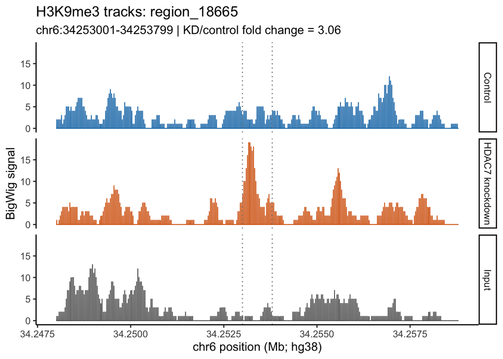

```r
locus_plot <- plot_locus_tracks(
  top_loci[1, , drop = FALSE]
)

locus_plot
```

### Save

```r
dir.create("figures", showWarnings = FALSE)

for (i in seq_len(nrow(top_loci))) {

  p <- plot_locus_tracks(
    top_loci[i, , drop = FALSE]
  )

  ggsave(
    filename = file.path(
      "figures",
      paste0(
        "H3K9me3_tracks_",
        top_loci$region_id[i],
        ".png"
      )
    ),
    plot = p,
    width = 10,
    height = 7,
    dpi = 300
  )
}
```

### tracks for the other two highest

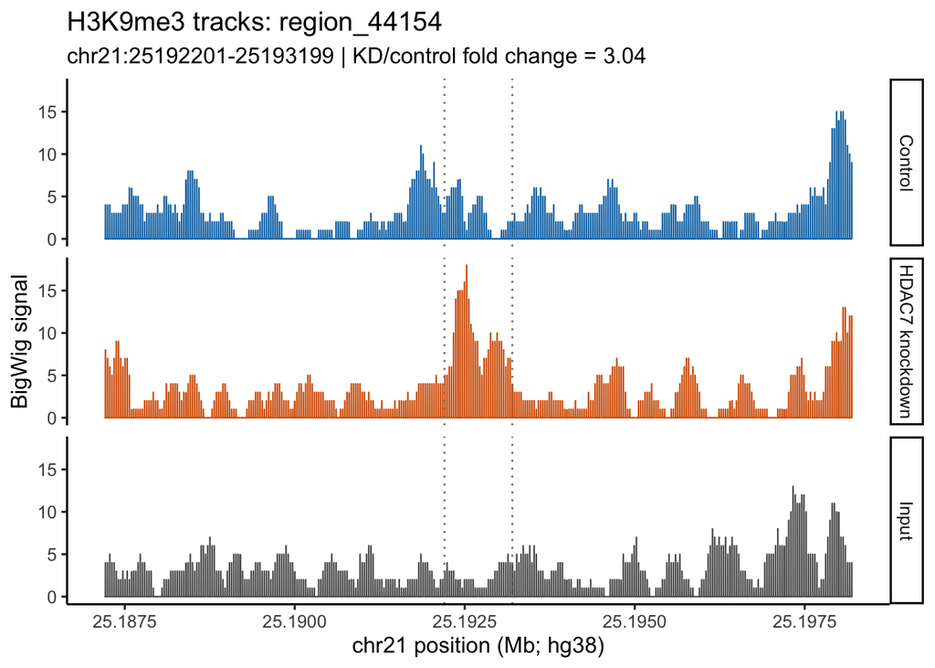

```r
plot_locus_tracks(
  top_loci[top_loci$region_id == "region_44154", , drop = FALSE]
)
```

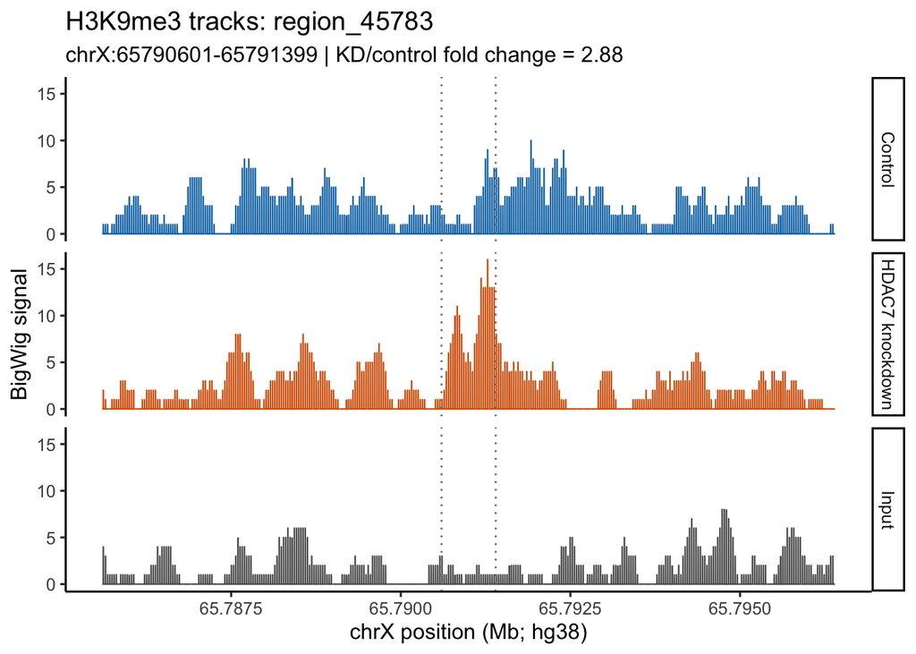

```r
plot_locus_tracks(
  top_loci[top_loci$region_id == "region_45783", , drop = FALSE]
)
```

```r
annotated_regions[
  annotated_regions$region_id == "region_18665",
  c(
    "region_id",
    "seqnames",
    "start",
    "end",
    "annotation",
    "SYMBOL",
    "geneId",
    "distanceToTSS",
    "control_mean",
    "knockdown_mean",
    "fold_change"
  )
]
```

```
##          region_id seqnames    start      end
## 18665 region_18665     chr6 34253001 34253799
##                                                        annotation SYMBOL geneId
## 18665 Intron (ENST00000586726.3/ENST00000586726.3, intron 1 of 2) SMIM29 221491
##       distanceToTSS control_mean knockdown_mean fold_change
## 18665         -3893   0.09637046      0.2953692    3.064935
```

```r
#SMIM29 is increased by 3 fold in KD compared to CT
```

```r
annotated_regions[
  annotated_regions$region_id == "region_44154",
  c(
    "region_id",
    "seqnames",
    "start",
    "end",
    "annotation",
    "SYMBOL",
    "geneId",
    "distanceToTSS",
    "control_mean",
    "knockdown_mean",
    "fold_change"
  )
]
```

```
##          region_id seqnames    start      end
## 44154 region_44154    chr21 25192201 25193199
##                                                        annotation    SYMBOL
## 44154 Intron (ENST00000409758.1/ENST00000409758.1, intron 1 of 3) LINC00158
##       geneId distanceToTSS control_mean knockdown_mean fold_change
## 44154  54072        206164    0.0970971      0.2952953    3.041237
```

```r
#LINC00158 is increased by 3 fold in KD compared to CT
```

```r
annotated_regions[
  annotated_regions$region_id == "region_45783",
  c(
    "region_id",
    "seqnames",
    "start",
    "end",
    "annotation",
    "SYMBOL",
    "geneId",
    "distanceToTSS",
    "control_mean",
    "knockdown_mean",
    "fold_change"
  )
]
```

```
##          region_id seqnames    start      end        annotation SYMBOL geneId
## 45783 region_45783     chrX 65790601 65791399 Distal Intergenic    MSN   4478
##       distanceToTSS control_mean knockdown_mean fold_change
## 45783        122947   0.09261577      0.2665832    2.878378
```

```r
#MSN is increased by 2.8 fold in KD compared to CT
```

### Interpretaion to follow up, HDAC7 knockdown increases H3K9me3 at an MSN-associated region, potentially contributing to reduced MSN expression and less aggressive cellular behavior.

```r
top_loci[
  ,
  c(
    "region_id",
    "seqnames",
    "start",
    "end",
    "SYMBOL",
    "annotation",
    "distanceToTSS",
    "fold_change"
  )
]
```

```
##          region_id seqnames    start      end    SYMBOL
## 18665 region_18665     chr6 34253001 34253799    SMIM29
## 44154 region_44154    chr21 25192201 25193199 LINC00158
## 45783 region_45783     chrX 65790601 65791399       MSN
##                                                        annotation distanceToTSS
## 18665 Intron (ENST00000586726.3/ENST00000586726.3, intron 1 of 2)         -3893
## 44154 Intron (ENST00000409758.1/ENST00000409758.1, intron 1 of 3)        206164
## 45783                                           Distal Intergenic        122947
##       fold_change
## 18665    3.064935
## 44154    3.041237
## 45783    2.878378
```

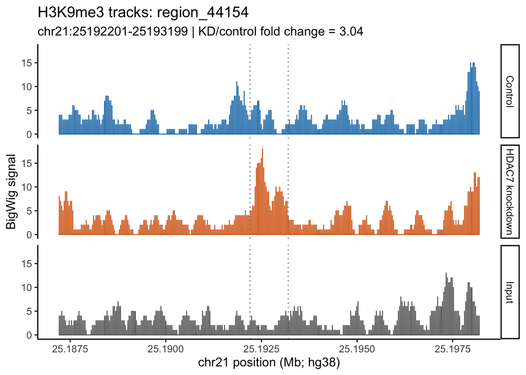

```r
plot_locus_tracks(
  top_loci[top_loci$region_id == "region_44154", , drop = FALSE]
)
```

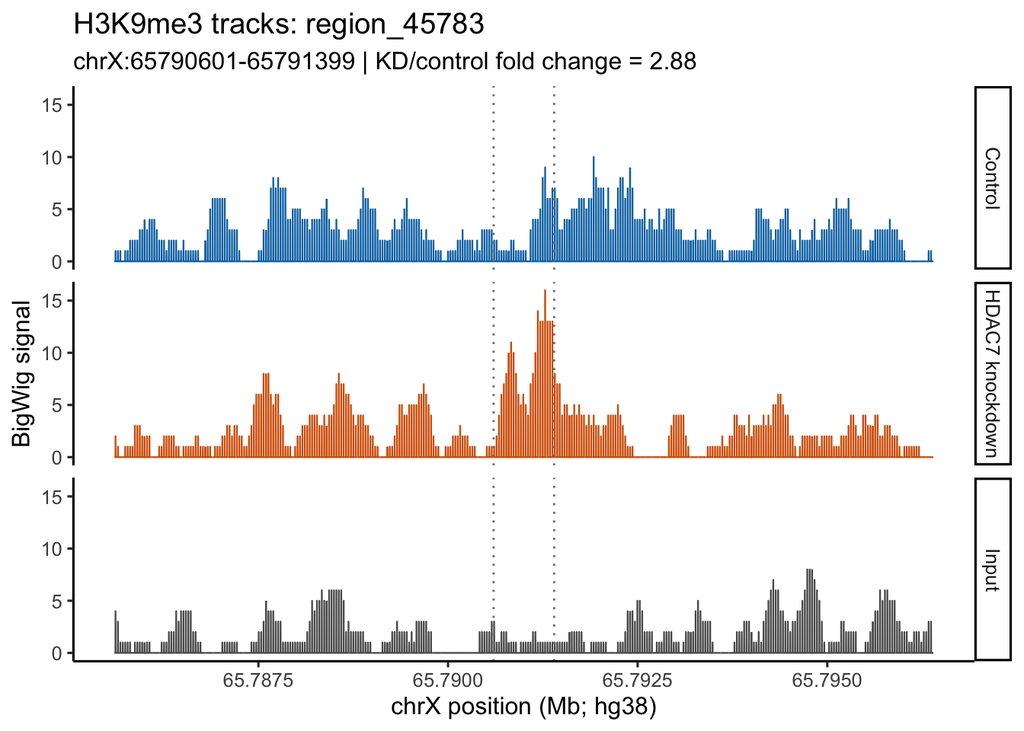

```r
plot_locus_tracks(
  top_loci[top_loci$region_id == "region_45783", , drop = FALSE]
)
```

## Data scope and analysis design:

**This notebook explores the publicly available H3K9me3 ChIP-seq tracks associated with the published study, using control, HDAC7 knockdown, and input data. It focuses on genomic coverage, signal visualization, and annotation of regions selected using an exploratory 1.5-fold change threshold. The analysis complements the publication by providing a reproducible workflow for examining the deposited tracks. Results are presented descriptively, with replicate-based statistical testing outside the scope of this notebook.**